# My visual data story

## The Data Collected Between me and my Friends

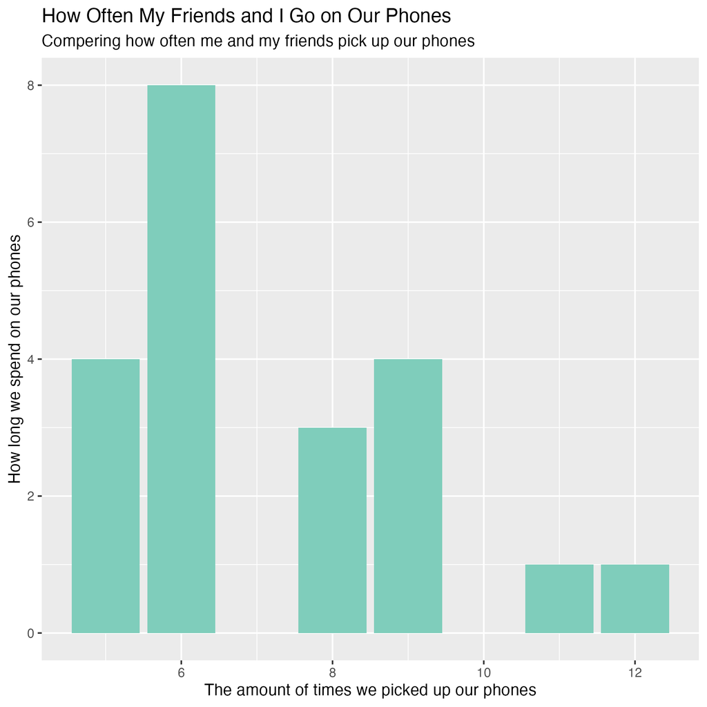

This data only uses me and my Friends phone usage

## All the Data to Show How Everyone uses Their Phones

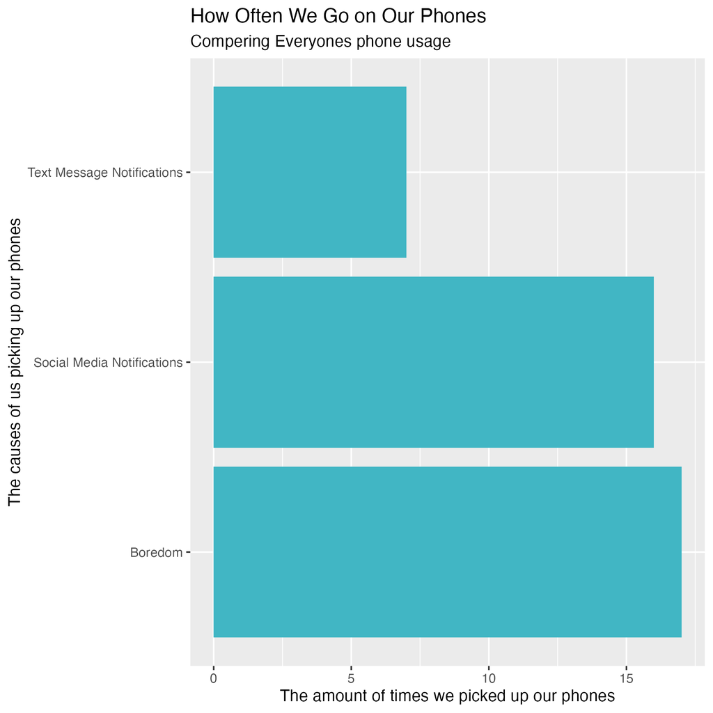

This graph shows the overall data

## Comparing the first rows between me, my brother and my friends

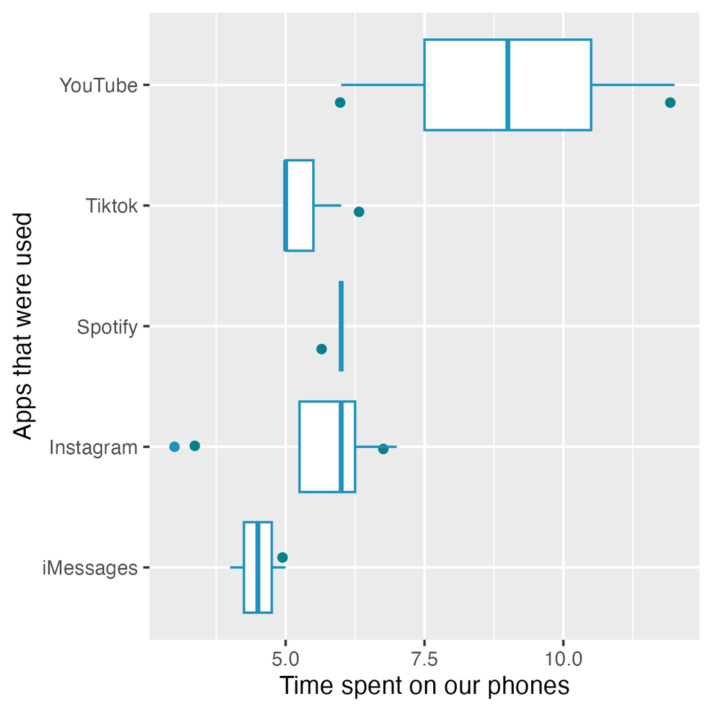

This graph shows the first rows from the original data and the new data

## Comparing the last rows between me, my brother and my friends

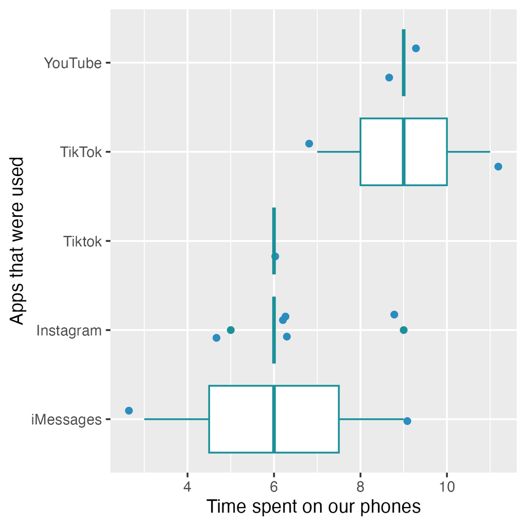

This graph shows the last rows from the original data and the new data

## Concluding ideas

In the beginning of collecting the data, the time spent on our phone is 5.9166667, and the average for the last rows of data collected is 7.1666667. While for the first rows of data collected, we can see that the average for how often we picked up our phone is 7.4166667, and for the last rows collected our average is 8.25.

By adding in my friends data on how they use their phone me and my brother are able to conclude that our phone usage is much higher and that its is a very unhealthy habit; my friends were also very interested and shocked by their phone usage as well because they haven’t put much thought into how often or how long they spent on their phones prior to this to my study.

Overall this was very interesting and also enjoyable as it allowed me to be more insightful of my screen time and also gave me the oppertunity to have a conversation about phone useage with my friends giving them insight.